# Climate Data: Earth surface temperature 1900 to 2012

Dataset pulled from [Kaggle](https://www.kaggle.com/berkeleyearth/climate-change-earth-surface-temperature-data#GlobalLandTemperaturesByCountry.csv).

This set of average monthly temperature data from Berkley goes as far back as 1743 for some countries. For this analysis, let's take a look at how things have changed post-industrialization. Climate science tells us each degree matters as far as impact to the planet so we are curious to find a baseline temperature and see how the yearly average for each country departs from our baseline.

First, we need to load the data into pandas as a dataframe.

```python
import pandas as pd
df = pd.read_csv('GlobalLandTemperaturesByCountry.csv')
```

Taking a quick peek around to see how the data is set up. Seeing some NaN values in the earliest years could mean several countries have incomplete readings making yearly averages inaccurate.

```python
df.head()
```

|  | dt | AverageTemperature | AverageTemperatureUncertainty | Country |
| --- | --- | --- | --- | --- |
| 0 | 1743-11-01 | 4.384 | 2.294 | Åland |
| 1 | 1743-12-01 | NaN | NaN | Åland |
| 2 | 1744-01-01 | NaN | NaN | Åland |
| 3 | 1744-02-01 | NaN | NaN | Åland |
| 4 | 1744-03-01 | NaN | NaN | Åland |

```python
df.info()
```

```
<class 'pandas.core.frame.DataFrame'>
RangeIndex: 577462 entries, 0 to 577461
Data columns (total 4 columns):
dt                               577462 non-null object
AverageTemperature               544811 non-null float64
AverageTemperatureUncertainty    545550 non-null float64
Country                          577462 non-null object
dtypes: float64(2), object(2)
memory usage: 17.6+ MB
```

Noting the column names and data types, I want to rename column "dt" as "Year" and change the data type to **datetime** with only the year displayed.

```python
df.columns =  ['Year', 'AverageTemperature','AverageTemperatureUncertainty', 'Country']
```

```python
df['Year'] = pd.to_datetime(df['Year']).dt.year
```

```python
df.head()
```

|  | Year | AverageTemperature | AverageTemperatureUncertainty | Country |
| --- | --- | --- | --- | --- |
| 0 | 1743 | 4.384 | 2.294 | Åland |
| 1 | 1743 | NaN | NaN | Åland |
| 2 | 1744 | NaN | NaN | Åland |
| 3 | 1744 | NaN | NaN | Åland |
| 4 | 1744 | NaN | NaN | Åland |

### Filter by year

Next we can filter out everything pre-1900. Before making any calculations, we want every Country to have a full 12 months of data in tact.

```python
df = df[(df.Year >=1900)]
df.head()
```

|  | Year | AverageTemperature | AverageTemperatureUncertainty | Country |
| --- | --- | --- | --- | --- |
| 1874 | 1900 | -3.026 | 0.538 | Åland |
| 1875 | 1900 | -8.063 | 0.657 | Åland |
| 1876 | 1900 | -3.196 | 0.467 | Åland |
| 1877 | 1900 | 0.781 | 0.224 | Åland |
| 1878 | 1900 | 4.960 | 0.503 | Åland |

Now let's check for NaN values

```python
df[df.isna().any(axis=1)]
```

|  | Year | AverageTemperature | AverageTemperatureUncertainty | Country |
| --- | --- | --- | --- | --- |
| 3238 | 2013 | NaN | NaN | Åland |
| 5344 | 2013 | NaN | NaN | Afghanistan |
| 7309 | 2013 | NaN | NaN | Africa |
| 10548 | 2013 | NaN | NaN | Albania |
| 13269 | 2013 | NaN | NaN | Algeria |
| 15030 | 2013 | NaN | NaN | American Samoa |
| 18269 | 2013 | NaN | NaN | Andorra |
| 20147 | 2013 | NaN | NaN | Angola |
| 22424 | 2013 | NaN | NaN | Anguilla |
| 22425 | 1950 | NaN | 2.107 | Antarctica |
| 22426 | 1950 | NaN | 2.168 | Antarctica |
| 22427 | 1950 | NaN | 2.197 | Antarctica |
| 22428 | 1950 | NaN | 2.249 | Antarctica |
| 22429 | 1950 | NaN | 2.504 | Antarctica |
| 22430 | 1950 | NaN | 2.331 | Antarctica |
| 22431 | 1950 | NaN | 2.026 | Antarctica |
| 22432 | 1950 | NaN | 2.276 | Antarctica |
| 22433 | 1950 | NaN | 2.279 | Antarctica |
| 22434 | 1950 | NaN | 2.015 | Antarctica |
| 22435 | 1950 | NaN | NaN | Antarctica |
| 22436 | 1951 | NaN | 2.006 | Antarctica |
| 22437 | 1951 | NaN | 2.032 | Antarctica |
| 22438 | 1951 | NaN | 2.205 | Antarctica |
| 22439 | 1951 | NaN | 1.985 | Antarctica |
| 22440 | 1951 | NaN | 2.080 | Antarctica |
| 22441 | 1951 | NaN | 2.511 | Antarctica |
| 22442 | 1951 | NaN | 2.068 | Antarctica |
| 22443 | 1951 | NaN | 2.345 | Antarctica |
| 22444 | 1951 | NaN | 2.406 | Antarctica |
| 22445 | 1951 | NaN | 1.954 | Antarctica |
| ... | ... | ... | ... | ... |
| 500481 | 2013 | NaN | NaN | Suriname |
| 503514 | 2013 | NaN | NaN | Svalbard And Jan Mayen |
| 505395 | 2013 | NaN | NaN | Swaziland |
| 508634 | 2013 | NaN | NaN | Sweden |
| 511873 | 2013 | NaN | NaN | Switzerland |
| 514333 | 2013 | NaN | NaN | Syria |
| 516406 | 2013 | NaN | NaN | Taiwan |
| 518575 | 2013 | NaN | NaN | Tajikistan |
| 520540 | 2013 | NaN | NaN | Tanzania |
| 522911 | 2013 | NaN | NaN | Thailand |
| 524538 | 2013 | NaN | NaN | Timor Leste |
| 526515 | 2013 | NaN | NaN | Togo |
| 528276 | 2013 | NaN | NaN | Tonga |
| 530553 | 2013 | NaN | NaN | Trinidad And Tobago |
| 533682 | 2013 | NaN | NaN | Tunisia |
| 536522 | 2013 | NaN | NaN | Turkey |
| 538859 | 2013 | NaN | NaN | Turkmenistan |
| 543113 | 2013 | NaN | NaN | Uganda |
| 546352 | 2013 | NaN | NaN | Ukraine |
| 548401 | 2013 | NaN | NaN | United Arab Emirates |
| 551640 | 2013 | NaN | NaN | United Kingdom (Europe) |
| 554879 | 2013 | NaN | NaN | United Kingdom |
| 560001 | 2013 | NaN | NaN | Uruguay |
| 562338 | 2013 | NaN | NaN | Uzbekistan |
| 564615 | 2013 | NaN | NaN | Venezuela |
| 566880 | 2013 | NaN | NaN | Vietnam |
| 571878 | 2013 | NaN | NaN | Western Sahara |
| 573531 | 2013 | NaN | NaN | Yemen |
| 575496 | 2013 | NaN | NaN | Zambia |
| 577461 | 2013 | NaN | NaN | Zimbabwe |

1050 rows × 4 columns

So there are still 1050 rows with at least 1 NaN data type. At this point, removing these rows will allow us to keep weeding out the incomplete data.

```python
df= df.dropna()
```

```python
df[df.isna().any(axis=1)] #Check again for NaN values
```

|  | Year | AverageTemperature | AverageTemperatureUncertainty | Country |
| --- | --- | --- | --- | --- |

### More Filtering

With all the incomplete temp readings and missing years of info, comparing each country won't be as easy. Maybe limiting our search to the top 10 countries in size would be another starting point. According to [World Atlas](https://www.worldatlas.com/articles/the-largest-countries-in-the-world-the-biggest-nations-as-determined-by-total-land-area.html), the top 10 largest countries make up 49% of the earth's landmass. They collectively span 5 different continents offering "every type of climate imaginable."

Using the countries from the World Atlas list, I'll filter our dataframe again...

```python
top10 = ['Algeria', 'Kazakhstan', 'Argentina', 'India', 'Australia', 'Brazil', 'China', 'United States', 'Canada', 'Russia']
```

```python
df = df[df.Country.isin(top10)]
```

```python
df.Country.unique()
```

```
array(['Algeria', 'Argentina', 'Australia', 'Brazil', 'Canada', 'China',
       'India', 'Kazakhstan', 'Russia', 'United States'], dtype=object)
```

Still looking for 12 months of temp measurements so I'll need to verify before we can start comparing averages from 1900 on. The following loop should tell us something.

```python
years= range(1900,2014)
for x in years:
    for y in top10:
        check= df[(df.Year==x) & (df.Country==y)].Year.value_counts() #Filter the dataframe to each Year and Country in our range and list. value_counts() will give us the number of occurences
        if (check.loc[x] < 12): #if value_count() for specific Year is less than 12
            print("Less than 12 months measured for " + str(x) + " in "+ y)
```

```
Less than 12 months measured for 2013 in Algeria
Less than 12 months measured for 2013 in Kazakhstan
Less than 12 months measured for 2013 in Argentina
Less than 12 months measured for 2013 in India
Less than 12 months measured for 2013 in Australia
Less than 12 months measured for 2013 in Brazil
Less than 12 months measured for 2013 in China
Less than 12 months measured for 2013 in United States
Less than 12 months measured for 2013 in Canada
Less than 12 months measured for 2013 in Russia
```

This is good news! We have a full 12 months of temp readings for our top 10 countries each year from 1900 up to 2012. We can drop 2013 since the full year isn't populated for some reason.

```python
df= df[df.Year != 2013] #remove 2013 from our date range
```

```python
df.tail()
```

|  | Year | AverageTemperature | AverageTemperatureUncertainty | Country |
| --- | --- | --- | --- | --- |
| 557807 | 2012 | 21.422 | 0.251 | United States |
| 557808 | 2012 | 17.036 | 0.185 | United States |
| 557809 | 2012 | 9.688 | 0.225 | United States |
| 557810 | 2012 | 3.330 | 0.120 | United States |
| 557811 | 2012 | -1.261 | 0.228 | United States |

### Averaging temperatures

Next we want to get the average yearly temperature by Country and be able to compare it to a baseline average from all the readings from 1900-2012. This will tell us if our yearly reading is above or below average and better determine if there is a general trend. Average yearly temp and temp uncertainty will be calculated as well.

```python
df["AverageYearlyTemp"] = df.groupby(["Country", "Year"])['AverageTemperature'].transform('mean')
df["AverageYearlyTempUncertainty"] = df.groupby(["Country", "Year"])['AverageTemperatureUncertainty'].transform('mean')
df["Top10AverageTemp"] = df.groupby(["Country"])["AverageYearlyTemp"].transform('mean') #Use this for baseline

df.head(20)
```

|  | Year | AverageTemperature | AverageTemperatureUncertainty | Country | AverageYearlyTemp | AverageYearlyTempUncertainty | Top10AverageTemp |
| --- | --- | --- | --- | --- | --- | --- | --- |
| 11905 | 1900 | 10.869 | 0.728 | Algeria | 22.864167 | 0.826667 | 23.255266 |
| 11906 | 1900 | 16.945 | 0.930 | Algeria | 22.864167 | 0.826667 | 23.255266 |
| 11907 | 1900 | 18.927 | 1.003 | Algeria | 22.864167 | 0.826667 | 23.255266 |
| 11908 | 1900 | 22.076 | 0.791 | Algeria | 22.864167 | 0.826667 | 23.255266 |
| 11909 | 1900 | 26.767 | 0.664 | Algeria | 22.864167 | 0.826667 | 23.255266 |
| 11910 | 1900 | 30.647 | 0.866 | Algeria | 22.864167 | 0.826667 | 23.255266 |
| 11911 | 1900 | 32.442 | 0.756 | Algeria | 22.864167 | 0.826667 | 23.255266 |
| 11912 | 1900 | 32.550 | 0.812 | Algeria | 22.864167 | 0.826667 | 23.255266 |
| 11913 | 1900 | 29.688 | 0.785 | Algeria | 22.864167 | 0.826667 | 23.255266 |
| 11914 | 1900 | 24.620 | 0.890 | Algeria | 22.864167 | 0.826667 | 23.255266 |
| 11915 | 1900 | 16.475 | 0.901 | Algeria | 22.864167 | 0.826667 | 23.255266 |
| 11916 | 1900 | 12.364 | 0.794 | Algeria | 22.864167 | 0.826667 | 23.255266 |
| 11917 | 1901 | 11.596 | 1.152 | Algeria | 22.726417 | 0.899667 | 23.255266 |
| 11918 | 1901 | 14.399 | 1.141 | Algeria | 22.726417 | 0.899667 | 23.255266 |
| 11919 | 1901 | 18.257 | 0.781 | Algeria | 22.726417 | 0.899667 | 23.255266 |
| 11920 | 1901 | 23.595 | 0.786 | Algeria | 22.726417 | 0.899667 | 23.255266 |
| 11921 | 1901 | 26.264 | 0.781 | Algeria | 22.726417 | 0.899667 | 23.255266 |
| 11922 | 1901 | 31.740 | 0.765 | Algeria | 22.726417 | 0.899667 | 23.255266 |
| 11923 | 1901 | 33.401 | 0.944 | Algeria | 22.726417 | 0.899667 | 23.255266 |
| 11924 | 1901 | 32.676 | 0.813 | Algeria | 22.726417 | 0.899667 | 23.255266 |

We can create another column with the annual temp change from baseline.

```python
df['AnnualTempChange'] = df['AverageYearlyTemp'] - df['Top10AverageTemp']
```

And last we can remove the monthly readings and have a single row of data for each year per country.

```python
df = df[["Year","Country","AverageYearlyTemp","AverageYearlyTempUncertainty","Top10AverageTemp","AnnualTempChange"]].drop_duplicates(keep ='last')
```

```python
df.head(50)
```

|  | Year | Country | AverageYearlyTemp | AverageYearlyTempUncertainty | Top10AverageTemp | AnnualTempChange |
| --- | --- | --- | --- | --- | --- | --- |
| 11916 | 1900 | Algeria | 22.864167 | 0.826667 | 23.255266 | -0.391100 |
| 11928 | 1901 | Algeria | 22.726417 | 0.899667 | 23.255266 | -0.528850 |
| 11940 | 1902 | Algeria | 23.052417 | 1.027083 | 23.255266 | -0.202850 |
| 11952 | 1903 | Algeria | 22.555667 | 0.941000 | 23.255266 | -0.699600 |
| 11964 | 1904 | Algeria | 22.682333 | 0.705500 | 23.255266 | -0.572933 |
| 11976 | 1905 | Algeria | 22.560083 | 0.825167 | 23.255266 | -0.695183 |
| 11988 | 1906 | Algeria | 22.468583 | 0.741083 | 23.255266 | -0.786683 |
| 12000 | 1907 | Algeria | 22.171583 | 0.840417 | 23.255266 | -1.083683 |
| 12012 | 1908 | Algeria | 22.829583 | 0.698250 | 23.255266 | -0.425683 |
| 12024 | 1909 | Algeria | 22.569833 | 0.737500 | 23.255266 | -0.685433 |
| 12036 | 1910 | Algeria | 22.676917 | 0.870583 | 23.255266 | -0.578350 |
| 12048 | 1911 | Algeria | 22.574667 | 0.715667 | 23.255266 | -0.680600 |
| 12060 | 1912 | Algeria | 22.866750 | 0.868833 | 23.255266 | -0.388516 |
| 12072 | 1913 | Algeria | 23.079250 | 0.744250 | 23.255266 | -0.176016 |
| 12084 | 1914 | Algeria | 23.043167 | 0.652333 | 23.255266 | -0.212100 |
| 12096 | 1915 | Algeria | 22.821167 | 0.794500 | 23.255266 | -0.434100 |
| 12108 | 1916 | Algeria | 22.643000 | 0.887750 | 23.255266 | -0.612266 |
| 12120 | 1917 | Algeria | 22.461167 | 1.018500 | 23.255266 | -0.794100 |
| 12132 | 1918 | Algeria | 22.411250 | 1.048917 | 23.255266 | -0.844016 |
| 12144 | 1919 | Algeria | 22.773333 | 0.954417 | 23.255266 | -0.481933 |
| 12156 | 1920 | Algeria | 23.094333 | 0.907667 | 23.255266 | -0.160933 |
| 12168 | 1921 | Algeria | 22.723583 | 0.945583 | 23.255266 | -0.531683 |
| 12180 | 1922 | Algeria | 22.934500 | 0.930500 | 23.255266 | -0.320766 |
| 12192 | 1923 | Algeria | 22.435750 | 0.770917 | 23.255266 | -0.819516 |
| 12204 | 1924 | Algeria | 23.418083 | 0.618000 | 23.255266 | 0.162817 |
| 12216 | 1925 | Algeria | 22.726583 | 0.667333 | 23.255266 | -0.528683 |
| 12228 | 1926 | Algeria | 23.501667 | 0.702833 | 23.255266 | 0.246400 |
| 12240 | 1927 | Algeria | 23.335417 | 0.581250 | 23.255266 | 0.080150 |
| 12252 | 1928 | Algeria | 23.115417 | 0.633417 | 23.255266 | -0.139850 |
| 12264 | 1929 | Algeria | 22.672083 | 0.627917 | 23.255266 | -0.583183 |
| 12276 | 1930 | Algeria | 23.454500 | 0.637250 | 23.255266 | 0.199234 |
| 12288 | 1931 | Algeria | 23.865833 | 0.624417 | 23.255266 | 0.610567 |
| 12300 | 1932 | Algeria | 23.616917 | 0.857750 | 23.255266 | 0.361650 |
| 12312 | 1933 | Algeria | 23.168500 | 0.662167 | 23.255266 | -0.086766 |
| 12324 | 1934 | Algeria | 22.744667 | 0.570500 | 23.255266 | -0.510600 |
| 12336 | 1935 | Algeria | 22.919750 | 0.466583 | 23.255266 | -0.335516 |
| 12348 | 1936 | Algeria | 22.940917 | 0.471917 | 23.255266 | -0.314350 |
| 12360 | 1937 | Algeria | 23.727500 | 0.448750 | 23.255266 | 0.472234 |
| 12372 | 1938 | Algeria | 22.727667 | 0.536417 | 23.255266 | -0.527600 |
| 12384 | 1939 | Algeria | 22.841417 | 0.520833 | 23.255266 | -0.413850 |
| 12396 | 1940 | Algeria | 23.005917 | 0.427500 | 23.255266 | -0.249350 |
| 12408 | 1941 | Algeria | 23.443417 | 0.460500 | 23.255266 | 0.188150 |
| 12420 | 1942 | Algeria | 23.610167 | 0.559750 | 23.255266 | 0.354900 |
| 12432 | 1943 | Algeria | 23.033333 | 0.599583 | 23.255266 | -0.221933 |
| 12444 | 1944 | Algeria | 22.934167 | 0.509333 | 23.255266 | -0.321100 |
| 12456 | 1945 | Algeria | 23.365500 | 0.431167 | 23.255266 | 0.110234 |
| 12468 | 1946 | Algeria | 23.254250 | 0.445333 | 23.255266 | -0.001016 |
| 12480 | 1947 | Algeria | 23.690167 | 0.430667 | 23.255266 | 0.434900 |
| 12492 | 1948 | Algeria | 23.071333 | 0.444833 | 23.255266 | -0.183933 |
| 12504 | 1949 | Algeria | 23.188167 | 0.441917 | 23.255266 | -0.067100 |

### Plotting

Now we can do some plotting visualizations with matplotlib

```python
import matplotlib.pyplot as plt
```

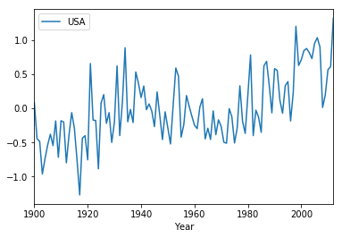

```python
df[df['Country']=='United States'].plot(x='Year', y='AnnualTempChange', label='USA')
```

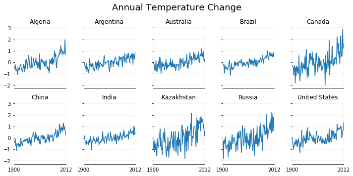

```python
fig, axes = plt.subplots(nrows=2, ncols=5, sharex=True, sharey=True, figsize=(10,5))
axes_list = [item for sublist in axes for item in sublist]
fig.suptitle('Annual Temperature Change', fontsize = 18)

first_year = df['Year'].min()
last_year = df['Year'].max()

for countryname, selection in df.groupby("Country"):
    ax = axes_list.pop(0)
    selection.plot(x='Year', y='AnnualTempChange', label=countryname, ax=ax, legend=False)
    ax.set_title(countryname)
    ax.tick_params(
    which='both',
    left= True,
    right= False,
    top= False,
    bottom= False
    )

    ax.grid(linewidth=0.25)
    ax.set_xlim((first_year, last_year))
    ax.set_ylabel("")
    ax.set_xlabel("")
    ax.set_xticks((first_year, last_year))
    ax.spines['left'].set_visible(False)
    ax.spines['top'].set_visible(False)
    ax.spines['right'].set_visible(False)



for ax in axes_list:
    ax.remove()

plt.tight_layout()
plt.subplots_adjust(top=0.85)
```

Some countries seem to have more fluctuations from year to year but in general we can see a positive trend with temperatures warming between 1900 and 2012.

```python
df.to_csv('climate_data_1900_2012.csv', index= None, header = True)
```

Tableau workbook below for more detail...

```python
%%HTML
<div class='tableauPlaceholder' id='viz1573789455768' style='position: relative'><noscript><a href='#'><img alt=' ' src='https:&#47;&#47;public.tableau.com&#47;static&#47;images&#47;cl&#47;climatedata&#47;Dashboard1&#47;1_rss.png' style='border: none' /></a></noscript><object class='tableauViz'  style='display:none;'><param name='host_url' value='https%3A%2F%2Fpublic.tableau.com%2F' /> <param name='embed_code_version' value='3' /> <param name='site_root' value='' /><param name='name' value='climatedata&#47;Dashboard1' /><param name='tabs' value='no' /><param name='toolbar' value='yes' /><param name='static_image' value='https:&#47;&#47;public.tableau.com&#47;static&#47;images&#47;cl&#47;climatedata&#47;Dashboard1&#47;1.png' /> <param name='animate_transition' value='yes' /><param name='display_static_image' value='yes' /><param name='display_spinner' value='yes' /><param name='display_overlay' value='yes' /><param name='display_count' value='yes' /><param name='filter' value='publish=yes' /></object></div>                <script type='text/javascript'>                    var divElement = document.getElementById('viz1573789455768');                    var vizElement = divElement.getElementsByTagName('object')[0];                    if ( divElement.offsetWidth > 800 ) { vizElement.style.minWidth='420px';vizElement.style.maxWidth='1250px';vizElement.style.width='100%';vizElement.style.minHeight='587px';vizElement.style.maxHeight='887px';vizElement.style.height=(divElement.offsetWidth*0.75)+'px';} else if ( divElement.offsetWidth > 500 ) { vizElement.style.minWidth='420px';vizElement.style.maxWidth='1250px';vizElement.style.width='100%';vizElement.style.minHeight='587px';vizElement.style.maxHeight='887px';vizElement.style.height=(divElement.offsetWidth*0.75)+'px';} else { vizElement.style.width='100%';vizElement.style.height='1127px';}                     var scriptElement = document.createElement('script');                    scriptElement.src = 'https://public.tableau.com/javascripts/api/viz_v1.js';                    vizElement.parentNode.insertBefore(scriptElement, vizElement);                </script>
```

[figure not shown]